# Scatter plots with marginal densities and repelling labels

Author

Michael Stadler, Charlotte Soneson

## Summary

This document illustrates how to use `ggExtra` and `ggrepel` together with `ggplot2` to:

- make a scatter plot that shows densities of points in the margins
- add labels to a scatter plot that do not overlap each other (repelling labels)

## Prepare data

Run the following code to prepare the data used in this document:

```r
suppressPackageStartupMessages({
    library(tibble)
})

# built-in `mtcars` dataset (see ?mtcars)
# ... convert some columns to factors
mycars <- mtcars
mycars$model <- rownames(mycars)
mycars$cyl <- factor(mycars$cyl, levels = c("4","6","8"))
mycars$engine_shape <- factor(c("0" = "V-shaped", "1" = "straight")[as.character(mycars$vs)])
mycars$transmission <- factor(c("0" = "automatic", "1" = "manual")[as.character(mycars$am)])

tibble(mycars)
```

```
# A tibble: 32 × 14
     mpg cyl    disp    hp  drat    wt  qsec    vs    am  gear  carb model
   <dbl> <fct> <dbl> <dbl> <dbl> <dbl> <dbl> <dbl> <dbl> <dbl> <dbl> <chr>
 1  21   6      160    110  3.9   2.62  16.5     0     1     4     4 Mazda RX4
 2  21   6      160    110  3.9   2.88  17.0     0     1     4     4 Mazda RX4 …
 3  22.8 4      108     93  3.85  2.32  18.6     1     1     4     1 Datsun 710
 4  21.4 6      258    110  3.08  3.22  19.4     1     0     3     1 Hornet 4 D…
 5  18.7 8      360    175  3.15  3.44  17.0     0     0     3     2 Hornet Spo…
 6  18.1 6      225    105  2.76  3.46  20.2     1     0     3     1 Valiant
 7  14.3 8      360    245  3.21  3.57  15.8     0     0     3     4 Duster 360
 8  24.4 4      147.    62  3.69  3.19  20       1     0     4     2 Merc 240D
 9  22.8 4      141.    95  3.92  3.15  22.9     1     0     4     2 Merc 230
10  19.2 6      168.   123  3.92  3.44  18.3     1     0     4     4 Merc 280
# ℹ 22 more rows
# ℹ 2 more variables: engine_shape <fct>, transmission <fct>
```

## Create figure

### Load packages

```r
library(ggplot2)
library(ggExtra)
library(ggrepel)
```

### Plot

Let’s start with a simple scatter plot that we want to annotate with marginal distributions and labels.

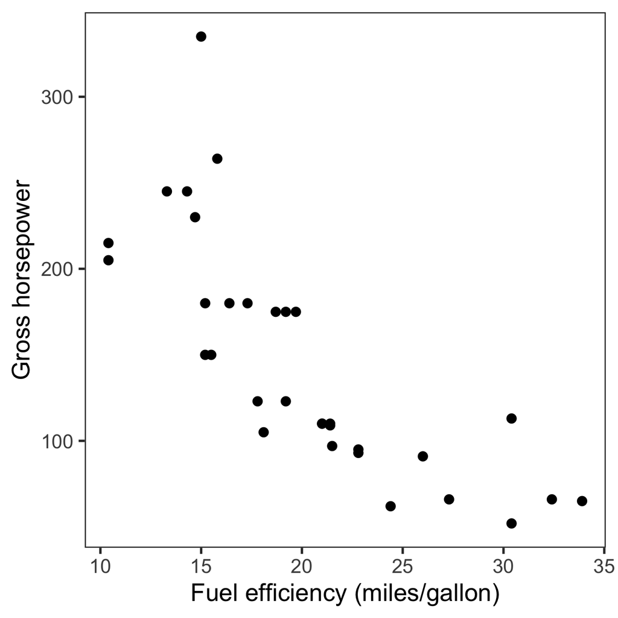

```r
# create base plot
p0 <- ggplot(data = mycars, mapping = aes(x = mpg, y = hp)) +
    geom_point() +
    labs(x = "Fuel efficiency (miles/gallon)", y = "Gross horsepower") +
    theme_bw(20) +
    theme(panel.grid = element_blank(),
          legend.position = "bottom")
p0
```

Now we add marginal histograms to show the distribution of observations when projected to the y- or x-axis.

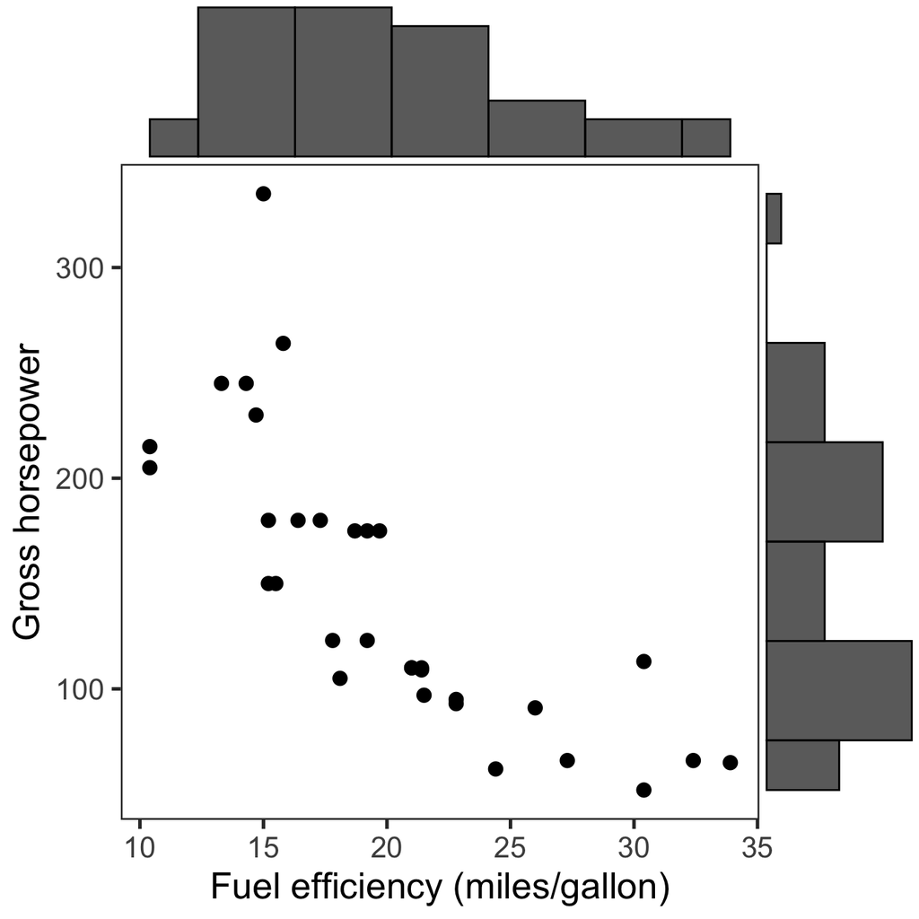

```r
# ... with marginal histograms
ggMarginal(p0, type = "histogram", margins = "both", size = 4, bins = 7)
```

We can also use density plots instead of histograms, and group our data, so that the distribution of each group is shown separately.

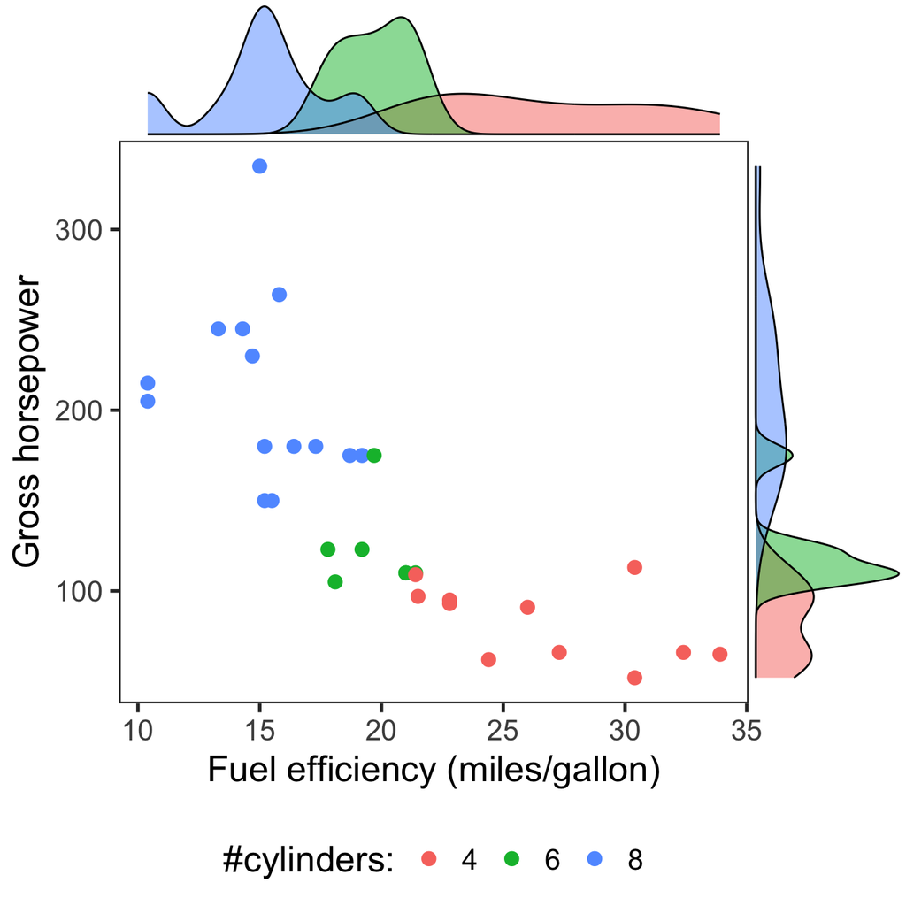

```r
# ... with marginal density plots by number of cylinders
ggMarginal(p0 +
               aes(fill = cyl, col = cyl) +
               labs(fill = "#cylinders:",
                    color = "#cylinders:"),
           type = "density", margins = "both", size = 4,
           groupFill = TRUE)
```

Finally, we use violin plots to show marginal distributions and add labels to our observations.

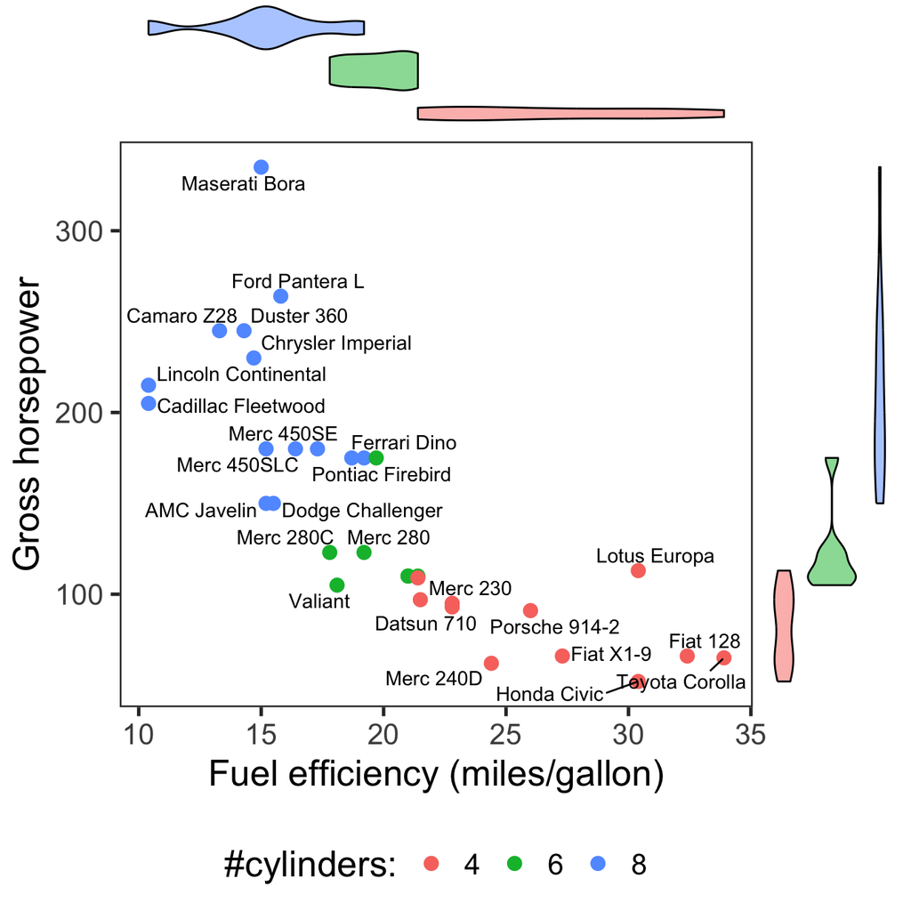

```r
# ... with marginal violin and labelled data points
ggMarginal(p0 +
               geom_text_repel(mapping = aes(label = model),
                               color = "black") +
               aes(fill = cyl, col = cyl) +
               labs(fill = "#cylinders:",
                    color = "#cylinders:"),
           type = "violin", margins = "both", size = 4,
           groupFill = TRUE)
```

## Remarks

- [`ggMarginal`](https://cran.r-project.org/web/packages/ggExtra/vignettes/ggExtra.html) requires either a `ggplot2` plot object with a `geom_point()` layer (argument `p`, as used above), or you can provide argument `data`, `x` and `y` instead.
- [`ggMarginal`](https://cran.r-project.org/web/packages/ggExtra/vignettes/ggExtra.html) supports different types of marginals (`type` argument): density, histogram, boxplot, violin, densigram.
- [`ggrepel`](https://cran.r-project.org/web/packages/ggrepel/vignettes/ggrepel.html) provides two major functions to add labels to a `ggplot2` figure: `geom_text_repel()` (the one we used above) just adds the labels, and `geom_label_repel()` which in addition draws a rectangle underneath the text, which may make the labels easier to read on crowded plots.